# Small variant detection with short read sequencing (Partie I : Alignement)

*École de bioinformatique INRAe-IFB-INSERM 2026*

- Maria BERNARD - INRAE

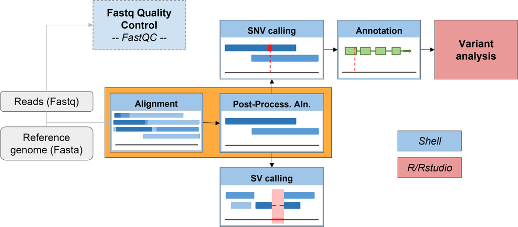

Vérifiez où vous êtes (`pwd`) et positionnez-vous dans le premier sous-projet : **TP_small_variants** (`cd`)

```bash
pwd
```

```
/shared/projects/2621_eb3in1_2026/atelier_variant/
```

```bash
cd TP_small_variants
```

Grâce à l'explorateur de fichiers, ouvrez le premier notebook : **01_Alignement_Processing-post-alignment.ipynb**

## I - Présentation du dispositif expérimental et de la procédure d'analyse.

Vous êtes chercheurs à INRAE dans une équipe qui travaille sur la génétique des bovins (a.k.a. Bos taurus).  
Par l'intermédiaire de l'[ONAB (l'Observatoire des Anomalies Bovines)](https://www.onab.fr/), des éleveurs vous communiquent une différence de couleur du pelage de certains animaux de race montbéliarde, c'est le **phénotype Milca**😉.

[figure not shown]

Vous faites des prélèvements sur 4 animaux, deux porteurs et 2 contrôles.  
Vous séquencez l'ADN (1 seule extraction) sur 3 lanes Illumina paired end (2x150 pb) par animal.

Votre objectif ? **identifier si une mutation génétique est à l'origine de ce phénotype et si oui laquelle.**

ℹ️ **Remarque**  
Le séquençage était évidemment plus important que cela. Pour les besoins du TP, j'ai extrait :

- seulement une partie des lanes,
- seulement les paires dont au moins une lecture correspondait au chromosome 2 (et éventuellement au chromosome 6).

Explorons le contenu du dossier. Pour cela vous pouvez utiliser la commande `ls` ou la commande `tree`

```bash
tree
```

```
.
├── 01_Alignement_Processing-post-alignment.ipynb
├── 02_VariantCalling_Annotation.ipynb
├── Annexe1_Baserecalibration.ipynb
├── Annexe2__GenomicsDB.ipynb
└── data
    ├── fastq
    │   ├── 40995_GGTGAACC-TCCAACGC-AHYGCWDSXY_L002_R1.fastq.gz
    │   ├── 40995_GGTGAACC-TCCAACGC-AHYGCWDSXY_L002_R2.fastq.gz
    └── genome
        ├── Bos_taurus_GCF_002263795.3_ARS-UCD2.0_chr2_chr6.fasta
        ├── Bos_taurus_GCF_002263795.3_ARS-UCD2.0_chr2_chr6.gff
        ├── Bos_taurus_GCF_002263795.3_ARS-UCD2.0_chr2_chr6_known_indels.vcf.gz
        ├── Bos_taurus_GCF_002263795.3_ARS-UCD2.0_chr2_chr6_known_indels.vcf.gz.tbi
        ├── Bos_taurus_GCF_002263795.3_ARS-UCD2.0_chr2_chr6_known_snps.vcf.gz
        └── Bos_taurus_GCF_002263795.3_ARS-UCD2.0_chr2_chr6_known_snps.vcf.gz.tbi

4 directories, 32 files
```

Pour regarder le contenu d'un fichier vous pouvez utiliser les commandes :

- `more FICHIER` ou `less FICHIER` si c'est un fichier texte (par exemple le fichier fasta du génome, plus de détails sur le format fasta)
- `zcat FICHIER | more` ou `zcat FICHIER | less` si c'est un fichier compressé (par exemple les fichiers fastq de séquençage, [plus de détails sur le format fastq](https://fr.wikipedia.org/wiki/FASTQ))

**Testez dans le Terminal !**  
Touche espace pour faire défiler, touche q pour quitter.

Pour ne pas vous perdre dans cette arborescence qui va évoluer, nous vous recommandons de créer un dossier **Results** puis d'alimenter ce dossier avec un dossier pour chaque grande étape.

Pour créer un dossier, vous utilisez la commande `mkdir`.

Créons un dossier `Results`.

```bash
mkdir -p Results
```

Pour contrôler dans quel dossier vous êtes et le contenu du dossier n'hésitez pas à relancer les commandes `pwd`, `ls` et/ou `tree`.

**Au programme**

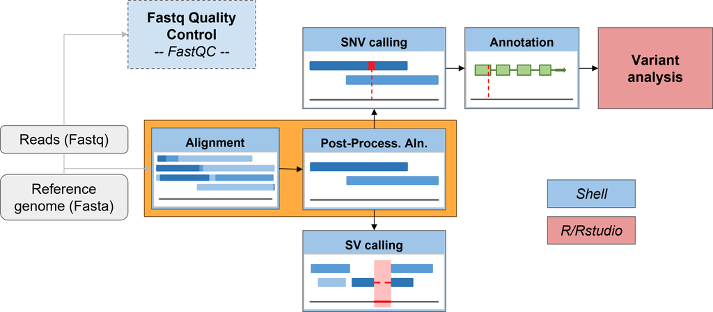

**Au programme**

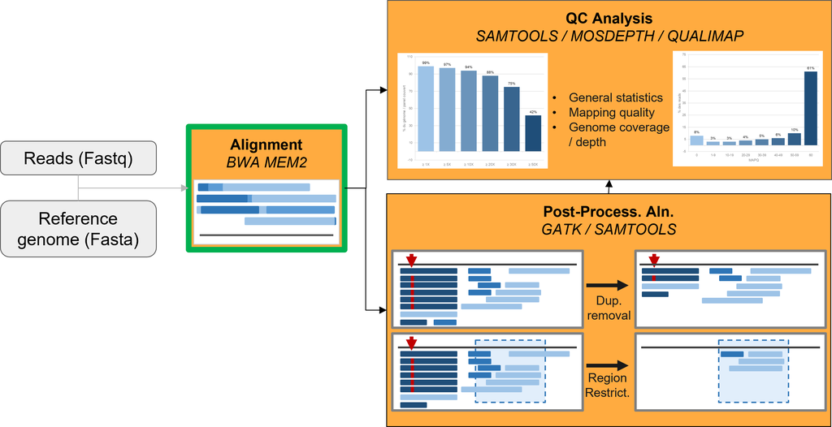

## II - Alignement

À partir des données de séquençage, généralement la première étape pour détecter une mutation ou génotyper des individus consiste à identifier la localisation des reads sur une séquence plus longue, le génome de référence. C'est ce que l'on appelle l'**alignement** des séquences.

C'est notre première grande étape, on commence donc par créer des sous-répertoires **Alignment** dans le dossier existant `Results`.

```bash
mkdir -p Results/Alignment
```

[BWA MEM2](https://github.com/bwa-mem2/bwa-mem2) est un logiciel d'alignement dont la particularité est d'utiliser la transformée de Burrows-Wheeler (Burrows-Wheeler Aligner) ce qui lui permet d'utiliser peu de mémoire.

On commence par charger le module bwa.

Rappel, pour trouver le nom du module `module avail TOOL_NAME` dans le Terminal!

```bash
module load bwa-mem2/2.2.1
```

Pour avoir accès à l'aide d'un outil, vous avez généralement 3 possibilités:

- écrire simplement le nom de l'outil
- utiliser le nom de l'outil et l'option `-h`, ou `--help` (ou plus rarement `-help`)
- Pour les commandes unix ... c'est un peu différent. On utilise `man CMD`.

Pour BWA, c'est simplement le nom de l'outil, testez!

```bash
bwa-mem2
```

```
Looking to launch executable "/shared/software/miniconda_deployment//envs/bwa-mem2-2.2.1/bin/bwa-mem2.avx512bw", simd = .avx512bw
Launching executable "/shared/software/miniconda_deployment//envs/bwa-mem2-2.2.1/bin/bwa-mem2.avx512bw"
Usage: bwa-mem2 <command> <arguments>
Commands:
  index         create index
  mem           alignment
  version       print version number
```

Ici on voit que bwa-mem2 propose 3 sous-commandes qui s'utilisent avec le schéma suivant :

```
Usage: bwa-mem2 <command> <arguments>
```

### 1. Indexation du génome

Comme la plupart des outils d'alignement (et bien d'autres encore), BWA a besoin que le génome de référence soit indexé, et chaque index est spécifique de chaque outil.

Sur la plupart des clusters de bioinformatique, il existe un répertoire partagé pour ces génomes et leurs index. Vous avez alors 2 possibilités:

- Votre génome est déjà présent sur le cluster, vous pouvez passer à l'étape d'alignement
- Votre génome n'est pas déjà sur le cluster, vous devez télécharger et indexer votre génome dans votre répertoire de travail (ou demander son installation!).

### 1.1 Où trouver son génome sur le cluster de l'IFB

Sur la [documentation du cluster](https://doc.cluster.france-bioinformatique.fr/data/banks/), il est indiqué que l'ensemble des banques partagées (dont les génomes et leurs index) sont disponibles dans `/shared/bank/`

Explorons le contenu avec la commande `ls` pour vérifier si le génome du bovin (*Bos taurus*, version ARS-UCD2.0) est présent et si l'index bwa-mem2 est déjà généré.

```bash
# ls /shared/bank/
# ls /shared/bank/bos_taurus/
ls /shared/bank/bos_taurus/ARS-UCD2.0/
# ls /shared/bank/bos_taurus/ARS-UCD2.0/*
```

```
fasta  gff  hisat2
```

A priori non, aucun index n'est déjà généré pour bwa-mem2 et le génome Bos_taurus ARS-UCD2.0.

### 1.2 Indexer son génome

Commençons par afficher l'aide du premier outil `bwa-mem2 index`

```bash
bwa-mem2 index
```

```
Looking to launch executable "/shared/software/miniconda_deployment//envs/bwa-mem2-2.2.1/bin/bwa-mem2.avx512bw", simd = .avx512bw
Launching executable "/shared/software/miniconda_deployment//envs/bwa-mem2-2.2.1/bin/bwa-mem2.avx512bw"
Usage: bwa-mem2 index [-p prefix] <in.fasta>
Total time taken: 0.0001
```

Le schéma de la commande est :

```
Usage: bwa-mem2 index [-p prefix] <in.fasta>
```

ℹ️ **Remarque**  
Par convention, tout ce qui est écrit entre `[]` est optionnel.

Indexez notre génome qui, pour rappel, se situe dans `data/genome/Bos_taurus_GCF_002263795.3_ARS-UCD2.0_chr2_chr6.fasta`

```bash
bwa-mem2 index data/genome/Bos_taurus_GCF_002263795.3_ARS-UCD2.0_chr2_chr6.fasta
```

Contrôlons ce que cela a changé en regardant le contenu du répertoire `data/genome` (commande `ls`, ou `tree`)

```bash
ls -lrth data/genome
# -l permet d'avoir une sortie détaillée
# -rt permet de trier les fichiers avec les plus récents à la fin.
# -h permet d'avoir le poids des fichiers "human readable"
# ==> -lrth est la combinaison de ces options ;-)
```

```
total 1.7G
-rw-r-----+ 1 mbernard mbernard 247M Jul 31 16:33 Bos_taurus_GCF_002263795.3_ARS-UCD2.0_chr2_chr6.fasta
-rw-r-----+ 1 mbernard mbernard  50M Jul 31 16:33 Bos_taurus_GCF_002263795.3_ARS-UCD2.0_chr2_chr6.gff
-rw-r-----+ 1 mbernard mbernard  19M Aug 14 09:33 Bos_taurus_GCF_002263795.3_ARS-UCD2.0_chr2_chr6_known_indels.vcf.gz
-rw-r-----+ 1 mbernard mbernard 140K Aug 14 09:33 Bos_taurus_GCF_002263795.3_ARS-UCD2.0_chr2_chr6_known_indels.vcf.gz.tbi
-rw-r-----+ 1 mbernard mbernard  90M Aug 14 09:33 Bos_taurus_GCF_002263795.3_ARS-UCD2.0_chr2_chr6_known_snps.vcf.gz
-rw-r-----+ 1 mbernard mbernard 181K Aug 14 09:33 Bos_taurus_GCF_002263795.3_ARS-UCD2.0_chr2_chr6_known_snps.vcf.gz.tbi
-rw-rw----+ 1 mbernard mbernard  61M Aug 21 12:58 Bos_taurus_GCF_002263795.3_ARS-UCD2.0_chr2_chr6.fasta.pac
-rw-rw----+ 1 mbernard mbernard   94 Aug 21 12:58 Bos_taurus_GCF_002263795.3_ARS-UCD2.0_chr2_chr6.fasta.ann
-rw-rw----+ 1 mbernard mbernard  255 Aug 21 12:58 Bos_taurus_GCF_002263795.3_ARS-UCD2.0_chr2_chr6.fasta.amb
-rw-rw----+ 1 mbernard mbernard 485M Aug 21 12:58 Bos_taurus_GCF_002263795.3_ARS-UCD2.0_chr2_chr6.fasta.0123
-rw-rw----+ 1 mbernard mbernard 788M Aug 21 12:59 Bos_taurus_GCF_002263795.3_ARS-UCD2.0_chr2_chr6.fasta.bwt.2bit.64
```